# Spatial Autocorrelation I

HES 505 Fall 2025: Session 25

Matt Williamson

# Objectives

By the end of today you should be able to:

- Use the `spdep` package to identify the neighbors of a given polygon based on proximity, distance, and minimum number
- Understand the underlying mechanics of Moran’s I and calculate it for various neighbors
- Distinguish between global and local measures of spatial autocorrelation
- Visualize neighbors and clusters

# Revisiting Spatial Autocorrelation

## The World Is Not Random

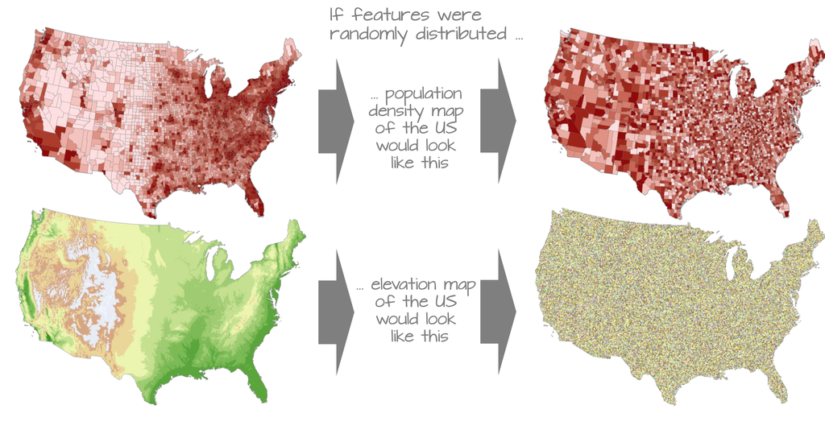

From Manuel Gimond

## Kriging Revisited

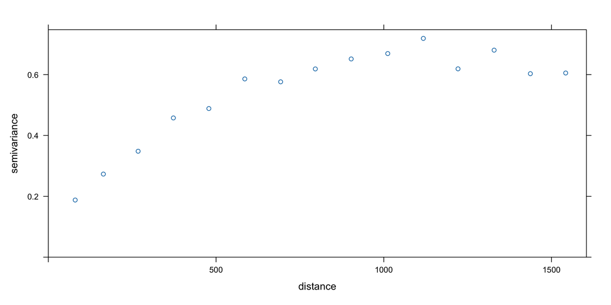

## Kriging Revisited

- Assumes autocorrelation to facilitate prediction
- Semivariogram decribes how autocorrelation changes with distance
- But what about statistical inference?

## Spatial Autocorrelation and Inference

- Attributes (features) are often non-randomly distributed
- Especially true with aggregated data
- Affects estimates of precision (and significance)

## Global Moran’s I

$$I = \frac{n}{W} \cdot \frac{\sum_{i=1}^{n}\sum_{j=1}^{n} w_{ij}(x_i - \bar{x})(x_j - \bar{x})}{\sum_{i=1}^{n}(x_i - \bar{x})^2}$$

where $W = \sum_{i=1}^{n}\sum_{j=1}^{n} w_{ij}$

- A *first-order* estimate of spatial autocorrelation

## Moran’s I

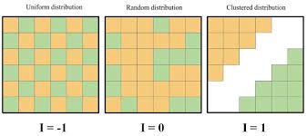

## …but How Do We Calculate $w_{i}$

- How do we define $I(d)$ for areal data?
- What about $w_{ij}$?
- We can use `spdep` for that!!

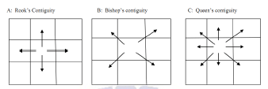

## Finding Neighbors

- Queen, rook, (and bishop) cases impose neighbors by contiguity
- Weights calculated as a $1/ num. of neighbors$

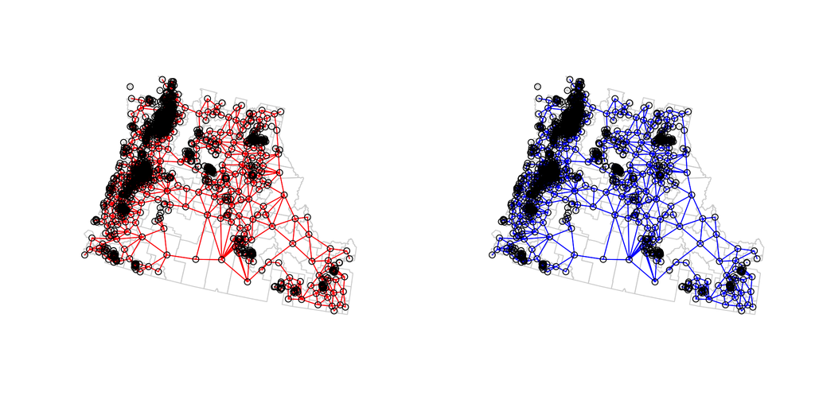

## More Formally

$$E[I] = \frac{-1}{n-1}$$

- When $n$ is large, E[I] approaches 0
- But large relative to what?

## Testing for Spatial Autocorrelation

- $I$ can be estimated by fitting a model of the lagged average as a function of the measurement

$$\mu_{lag} = \beta \times measurement$$

where $\beta = I$

## Comparing observed to expected

- We can generate the expected distribution of Moran’s I coefficients under a Null hypothesis of no spatial autocorrelation
- Using permutation and a loop to generate simulations of Moran’s I

## Significance testing

- Pseudo p-value (based on permutations)
- Analytically (sensitive to deviations from assumptions)
- Using Monte Carlo

## Local Indicators of Spatial Autocorrelation

- Sometimes we want to know about *second-order* autocorrelation
- Is there clustering around different locations (but maybe not everywhere)?

## Local Moran’s I

$$I_i = \frac{(x_i - \bar{x})}{\sum_{k=1}^{n}(x_k - \bar{x})^2/n} \sum_{j=1}^{n} w_{ij}(x_j - \bar{x})$$

- Can identify areas where clustering is great than expected
- Proportional to Global Moran’s I

## Autocorrelation and Inference

- Interpolation assumes autocorrelation
- Inference is interested in mechanisms
- Tests for mechanisms get confused by autocorrelation
- Diagnosing autocorrelation helps plan next steps (Weds)